# STEPS Study: Objective 3 - Comparison with guidelines and recommendations

C. Konstantinou and X. Andrianou @ Water and Health Laboratory, CII-CUT

Data points will be categorized as below, within and above cut-offs following recommendations or guidelines on environmental exposures.

### Temperature

22°C-27°C for classrooms (category III, summer), 23°C-26°C for classrooms (category III, summer), 23.5°C-25.5°C for classrooms (category I, summer) - European Performance Per Building Directive - https://www.rehva.eu/rehva-journal/chapter/new-health-comfort-promoting-cen-standard

### Rel. Humidity:

40-60% (ASHRAE Guidelines and Harvard Healthy Building Program) - https://schools.forhealth.org/wp-content/uploads/sites/19/2020/11/Harvard-Healthy-Buildings-Program-COVID19-Risk-Reduction-in-Schools-Nov-2020.pdf

### CO2

1. 1350 ppm for classrooms (category III), 800 ppm for classrooms (category II), 550 ppm for classrooms (category I) - European Performance Per Building Directive - https://www.rehva.eu/rehva-journal/chapter/new-health-comfort-promoting-cen-standard
2. Harvard tool to calculate optimal CO2 - https://schools.forhealth.org/wp-content/uploads/sites/19/2020/08/Harvard-Healthy-Buildings-program-How-to-assess-classroom-ventilation-08-28-2020.pdf

### PM2.5 (24h)

15 ug/m3 (WHO 2021 AQG, https://www.who.int/news-room/feature-stories/detail/what-are-the-who-air-quality-guidelines )

### PM10 (24h)

1. 45 ug/m3 (WHO 2021 AQG, https://www.who.int/news-room/feature-stories/detail/what-are-the-who-air-quality-guidelines)
2. 50 ug/m3 (https://eur-lex.europa.eu/legal-content/EN/TXT/PDF/?uri=CELEX:32008L0050&from=en)

### 1b. Compare classroom temperatures with European Performance of Buildings Directive (EPBD) guidelines - 22°C-27°C for classrooms (category III, summer) - only school hours

https://www.rehva.eu/rehva-journal/chapter/new-health-comfort-promoting-cen-standard

Temperature data categorization during school hours for classrooms

| n | categories | n_per_category | perc_per_category |
| --- | --- | --- | --- |
| 2450 | >27°C | 2080 | 85 |
| 2450 | 22°C-27°C | 370 | 15 |

Temperature data categorization during school hours for classrooms - by district and degree of urbanization

| district | degurba | n | categories | n_per_category | perc_per_category |
| --- | --- | --- | --- | --- | --- |
| Famagusta | 2 | 109 | >27°C | 82 | 75 |
| Famagusta | 2 | 109 | 22°C-27°C | 27 | 25 |
| Larnaka | 1 | 307 | >27°C | 166 | 54 |
| Larnaka | 1 | 307 | 22°C-27°C | 141 | 46 |
| Larnaka | 2 | 237 | >27°C | 206 | 87 |
| Larnaka | 2 | 237 | 22°C-27°C | 31 | 13 |
| Limassol | 1 | 446 | >27°C | 360 | 81 |
| Limassol | 1 | 446 | 22°C-27°C | 86 | 19 |
| Limassol | 2 | 194 | >27°C | 194 | 100 |
| Limassol | 2 | 194 | 22°C-27°C | 0 | 0 |
| Nicosia | 1 | 697 | >27°C | 675 | 97 |
| Nicosia | 1 | 697 | 22°C-27°C | 22 | 3 |
| Nicosia | 2 | 126 | >27°C | 126 | 100 |
| Nicosia | 2 | 126 | 22°C-27°C | 0 | 0 |
| Paphos | 2 | 334 | >27°C | 271 | 81 |
| Paphos | 2 | 334 | 22°C-27°C | 63 | 19 |

### 2. Compare classrooms’ relative humidity with ASHRAE guidelines and Harvard School of Public Health https://schools.forhealth.org/wp-content/uploads/sites/19/2020/11/Harvard-Healthy-Buildings-Program-COVID19-Risk-Reduction-in-Schools-Nov-2020.pdf (40-60%) - only school hours

Rel. humidity data categorization during school hours for classrooms

| n | categories | n_per_category | perc_per_category |
| --- | --- | --- | --- |
| 2450 | <40% | 684 | 28 |
| 2450 | >60% | 187 | 8 |
| 2450 | 40% - 60% | 1579 | 64 |

Rel. humidity data categorization during school hours for classrooms - by district and degree of urbanization

| district | degurba | n | categories | n_per_category | perc_per_category |
| --- | --- | --- | --- | --- | --- |
| Famagusta | 2 | 109 | <40% | 38 | 35 |
| Famagusta | 2 | 109 | >60% | 1 | 1 |
| Famagusta | 2 | 109 | 40% - 60% | 70 | 64 |
| Larnaka | 1 | 307 | <40% | 1 | 0 |
| Larnaka | 1 | 307 | >60% | 85 | 28 |
| Larnaka | 1 | 307 | 40% - 60% | 221 | 72 |
| Larnaka | 2 | 237 | <40% | 25 | 11 |
| Larnaka | 2 | 237 | >60% | 33 | 14 |
| Larnaka | 2 | 237 | 40% - 60% | 179 | 76 |
| Limassol | 1 | 446 | <40% | 34 | 8 |
| Limassol | 1 | 446 | >60% | 28 | 6 |
| Limassol | 1 | 446 | 40% - 60% | 384 | 86 |
| Limassol | 2 | 194 | <40% | 36 | 19 |
| Limassol | 2 | 194 | >60% | 0 | 0 |
| Limassol | 2 | 194 | 40% - 60% | 158 | 81 |
| Nicosia | 1 | 697 | <40% | 415 | 60 |
| Nicosia | 1 | 697 | >60% | 0 | 0 |
| Nicosia | 1 | 697 | 40% - 60% | 282 | 40 |
| Nicosia | 2 | 126 | <40% | 102 | 81 |
| Nicosia | 2 | 126 | >60% | 0 | 0 |
| Nicosia | 2 | 126 | 40% - 60% | 24 | 19 |
| Paphos | 2 | 334 | <40% | 33 | 10 |
| Paphos | 2 | 334 | >60% | 40 | 12 |
| Paphos | 2 | 334 | 40% - 60% | 261 | 78 |

### 3a. Compare classrooms’ C02 with European Performance of Buildings Directive (EPBD) guidelines - 1350 ppm for classrooms (category III), 800 ppm for classrooms (category II) - school hoors

https://www.rehva.eu/rehva-journal/chapter/new-health-comfort-promoting-cen-standard

Carbon dioxide data categorization during school hours for classrooms - European Performance of Buildings Directive (EPBD) guidelines

| n | categories | n_per_category | perc_per_category |
| --- | --- | --- | --- |
| 2450 | <= 800 ppm | 2390 | 98 |
| 2450 | >1350 ppm | 11 | 0 |
| 2450 | 800-1350 ppm | 49 | 2 |

Carbon dioxide data categorization during school hours for classrooms - European Performance of Buildings Directive (EPBD) guidelines - by district and degree of urbanization

| district | degurba | n | categories | n_per_category | perc_per_category |
| --- | --- | --- | --- | --- | --- |
| Famagusta | 2 | 109 | <= 800 ppm | 107 | 98 |
| Famagusta | 2 | 109 | >1350 ppm | 0 | 0 |
| Famagusta | 2 | 109 | 800-1350 ppm | 2 | 2 |
| Larnaka | 1 | 307 | <= 800 ppm | 305 | 99 |
| Larnaka | 1 | 307 | >1350 ppm | 0 | 0 |
| Larnaka | 1 | 307 | 800-1350 ppm | 2 | 1 |
| Larnaka | 2 | 237 | <= 800 ppm | 237 | 100 |
| Larnaka | 2 | 237 | >1350 ppm | 0 | 0 |
| Larnaka | 2 | 237 | 800-1350 ppm | 0 | 0 |
| Limassol | 1 | 446 | <= 800 ppm | 417 | 93 |
| Limassol | 1 | 446 | >1350 ppm | 11 | 2 |
| Limassol | 1 | 446 | 800-1350 ppm | 18 | 4 |
| Limassol | 2 | 194 | <= 800 ppm | 191 | 98 |
| Limassol | 2 | 194 | >1350 ppm | 0 | 0 |
| Limassol | 2 | 194 | 800-1350 ppm | 3 | 2 |
| Nicosia | 1 | 697 | <= 800 ppm | 680 | 98 |
| Nicosia | 1 | 697 | >1350 ppm | 0 | 0 |
| Nicosia | 1 | 697 | 800-1350 ppm | 17 | 2 |
| Nicosia | 2 | 126 | <= 800 ppm | 122 | 97 |
| Nicosia | 2 | 126 | >1350 ppm | 0 | 0 |
| Nicosia | 2 | 126 | 800-1350 ppm | 4 | 3 |
| Paphos | 2 | 334 | <= 800 ppm | 331 | 99 |
| Paphos | 2 | 334 | >1350 ppm | 0 | 0 |
| Paphos | 2 | 334 | 800-1350 ppm | 3 | 1 |

### 3b. Compare classrooms’ C02 with optimal CO2 based on average number of children, average classroom area and average OD CO2 - Harvard Health Buildings program - Steady State CO2 Method

Carbon dioxide data categorization during school hours for classrooms - using the Steady State CO2 Method

| n | categories | n_per_category | perc_per_category |
| --- | --- | --- | --- |
| 2450 | <=866 ppm | 2408 | 98 |
| 2450 | >866 ppm | 42 | 2 |

Carbon dioxide data categorization during school hours for classrooms - using the Steady State CO2 Method - by district and degree of urbanization

| district | degurba | n | categories | n_per_category | perc_per_category |
| --- | --- | --- | --- | --- | --- |
| Famagusta | 2 | 109 | <=866 ppm | 107 | 98 |
| Famagusta | 2 | 109 | >866 ppm | 2 | 2 |
| Larnaka | 1 | 307 | <=866 ppm | 307 | 100 |
| Larnaka | 1 | 307 | >866 ppm | 0 | 0 |
| Larnaka | 2 | 237 | <=866 ppm | 237 | 100 |
| Larnaka | 2 | 237 | >866 ppm | 0 | 0 |
| Limassol | 1 | 446 | <=866 ppm | 421 | 94 |
| Limassol | 1 | 446 | >866 ppm | 25 | 6 |
| Limassol | 2 | 194 | <=866 ppm | 192 | 99 |
| Limassol | 2 | 194 | >866 ppm | 2 | 1 |
| Nicosia | 1 | 697 | <=866 ppm | 687 | 99 |
| Nicosia | 1 | 697 | >866 ppm | 10 | 1 |
| Nicosia | 2 | 126 | <=866 ppm | 125 | 99 |
| Nicosia | 2 | 126 | >866 ppm | 1 | 1 |
| Paphos | 2 | 334 | <=866 ppm | 332 | 99 |
| Paphos | 2 | 334 | >866 ppm | 2 | 1 |

## 4. PM2.5 (24h): 15 ug/m3 (WHO 2021 AQG, https://www.who.int/news-room/feature-stories/detail/what-are-the-who-air-quality-guidelines)

PM2.5 data categorization for 24-hour means - by location

| indoor_outdoor | n | categories | n_per_category | perc_per_category |
| --- | --- | --- | --- | --- |
| indoors | 73 | >15 ug/m3 | 39 | 53 |
| indoors | 73 | <=15 ug/m3 | 34 | 47 |
| outdoors | 35 | >15 ug/m3 | 10 | 29 |
| outdoors | 35 | <=15 ug/m3 | 25 | 71 |

Indoor PM2.5 data categorization for 24-hour means - by district, degurba

| district | degurba | n | categories | n_per_category | perc_per_category |
| --- | --- | --- | --- | --- | --- |
| Famagusta | 2 | 3 | >15 ug/m3 | 1 | 33 |
| Famagusta | 2 | 3 | <=15 ug/m3 | 2 | 67 |
| Larnaka | 1 | 10 | >15 ug/m3 | 1 | 10 |
| Larnaka | 1 | 10 | <=15 ug/m3 | 9 | 90 |
| Larnaka | 2 | 6 | >15 ug/m3 | 6 | 100 |
| Larnaka | 2 | 6 | <=15 ug/m3 | 0 | 0 |
| Limassol | 1 | 16 | >15 ug/m3 | 7 | 44 |
| Limassol | 1 | 16 | <=15 ug/m3 | 9 | 56 |
| Limassol | 2 | 2 | >15 ug/m3 | 0 | 0 |
| Limassol | 2 | 2 | <=15 ug/m3 | 2 | 100 |
| Nicosia | 1 | 23 | >15 ug/m3 | 16 | 70 |
| Nicosia | 1 | 23 | <=15 ug/m3 | 7 | 30 |
| Nicosia | 2 | 3 | >15 ug/m3 | 1 | 33 |
| Nicosia | 2 | 3 | <=15 ug/m3 | 2 | 67 |
| Paphos | 2 | 10 | >15 ug/m3 | 7 | 70 |
| Paphos | 2 | 10 | <=15 ug/m3 | 3 | 30 |

## 5A. PM10 (24h): 45 ug/m3 (WHO 2021 AQG, https://www.who.int/news-room/feature-stories/detail/what-are-the-who-air-quality-guidelines)

PM10 data categorization for 24-hour means - by location

| indoor_outdoor | n | categories | n_per_category | perc_per_category |
| --- | --- | --- | --- | --- |
| indoors | 73 | <=45 ug/m3 | 72 | 99 |
| indoors | 73 | >45 ug/m3 | 1 | 1 |
| outdoors | 34 | <=45 ug/m3 | 34 | 100 |
| outdoors | 34 | >45 ug/m3 | 0 | 0 |

Indoor PM10 data categorization for 24-hour means - by district, degurba

| district | degurba | n | categories | n_per_category | perc_per_category |
| --- | --- | --- | --- | --- | --- |
| Famagusta | 2 | 3 | <=45 ug/m3 | 3 | 100 |
| Famagusta | 2 | 3 | >45 ug/m3 | 0 | 0 |
| Larnaka | 1 | 10 | <=45 ug/m3 | 10 | 100 |
| Larnaka | 1 | 10 | >45 ug/m3 | 0 | 0 |
| Larnaka | 2 | 4 | <=45 ug/m3 | 3 | 75 |
| Larnaka | 2 | 4 | >45 ug/m3 | 1 | 25 |
| Limassol | 1 | 17 | <=45 ug/m3 | 17 | 100 |
| Limassol | 1 | 17 | >45 ug/m3 | 0 | 0 |
| Limassol | 2 | 3 | <=45 ug/m3 | 3 | 100 |
| Limassol | 2 | 3 | >45 ug/m3 | 0 | 0 |
| Nicosia | 1 | 23 | <=45 ug/m3 | 23 | 100 |
| Nicosia | 1 | 23 | >45 ug/m3 | 0 | 0 |
| Nicosia | 2 | 3 | <=45 ug/m3 | 3 | 100 |
| Nicosia | 2 | 3 | >45 ug/m3 | 0 | 0 |
| Paphos | 2 | 10 | <=45 ug/m3 | 10 | 100 |
| Paphos | 2 | 10 | >45 ug/m3 | 0 | 0 |

## 5B PM10 50 ug/m3 (https://eur-lex.europa.eu/legal-content/EN/TXT/PDF/?uri=CELEX:32008L0050&from=en)

PM10 data categorization for 24-hour means - by location

| indoor_outdoor | n | categories | n_per_category | perc_per_category |
| --- | --- | --- | --- | --- |
| indoors | 73 | <=50 ug/m3 | 72 | 99 |
| indoors | 73 | >50 ug/m3 | 1 | 1 |
| outdoors | 34 | <=50 ug/m3 | 34 | 100 |
| outdoors | 34 | >50 ug/m3 | 0 | 0 |

Indoor PM10 data categorization for 24-hour means - by district

| district | degurba | n | categories | n_per_category | perc_per_category |
| --- | --- | --- | --- | --- | --- |
| Famagusta | 2 | 3 | <=50 ug/m3 | 3 | 100 |
| Famagusta | 2 | 3 | >50 ug/m3 | 0 | 0 |
| Larnaka | 1 | 10 | <=50 ug/m3 | 10 | 100 |
| Larnaka | 1 | 10 | >50 ug/m3 | 0 | 0 |
| Larnaka | 2 | 4 | <=50 ug/m3 | 3 | 75 |
| Larnaka | 2 | 4 | >50 ug/m3 | 1 | 25 |
| Limassol | 1 | 17 | <=50 ug/m3 | 17 | 100 |
| Limassol | 1 | 17 | >50 ug/m3 | 0 | 0 |
| Limassol | 2 | 3 | <=50 ug/m3 | 3 | 100 |
| Limassol | 2 | 3 | >50 ug/m3 | 0 | 0 |
| Nicosia | 1 | 23 | <=50 ug/m3 | 23 | 100 |
| Nicosia | 1 | 23 | >50 ug/m3 | 0 | 0 |
| Nicosia | 2 | 3 | <=50 ug/m3 | 3 | 100 |
| Nicosia | 2 | 3 | >50 ug/m3 | 0 | 0 |
| Paphos | 2 | 10 | <=50 ug/m3 | 10 | 100 |
| Paphos | 2 | 10 | >50 ug/m3 | 0 | 0 |

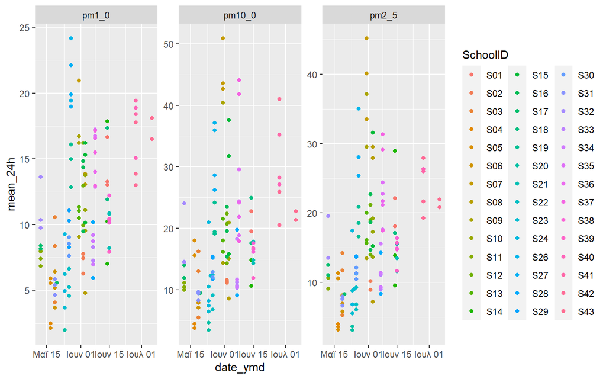

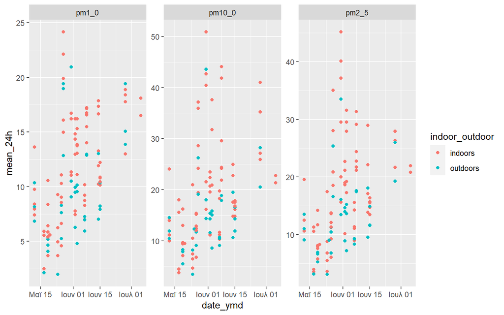